# Machine Learning Project

Damien Edwards

March 15, 2015

## Background

Using devices such as Jawbone Up, Nike FuelBand, and Fitbit it is now possible to collect a large amount of data about personal activity relatively inexpensively. These type of devices are part of the quantified self movement – a group of enthusiasts who take measurements about themselves regularly to improve their health, to find patterns in their behavior, or because they are tech geeks. One thing that people regularly do is quantify how much of a particular activity they do, but they rarely quantify how well they do it. In this project, your goal will be to use data from accelerometers on the belt, forearm, arm, and dumbell of 6 participants. They were asked to perform barbell lifts correctly and incorrectly in 5 different ways. More information is available from the website here: http://groupware.les.inf.puc-rio.br/har (see the section on the Weight Lifting Exercise Dataset).

## Data

The training data for this project are available here:

https://d396qusza40orc.cloudfront.net/predmachlearn/pml-training.csv

The test data are available here:

https://d396qusza40orc.cloudfront.net/predmachlearn/pml-testing.csv

## Model

The outcome variable is classe- a factor variable with 5 levels. - exactly according to the specification (Class A) - throwing the elbows to the front (Class B) - lifting the dumbbell only halfway (Class C) - lowering the dumbbell only halfway (Class D) - throwing the hips to the front (Class E)

### Cross-validation

The cross-validation will be performed using a subset of the training data set without replacement into 2 subsets. Our model will be fiited to the subTraining data set and tested on the subTest data set. Once the accurate model is determined it will be tested on the original Testing data set.

### Expected out-of-sample error

Expected out-of-smample error will correspond to the accuracy in the cross-validation data.Expected number of missclassified observations will be the expected value of the out-of-sample error.

### Modeling choices

The variable classe is unordered factor variable. I will use Decision Tree and random forest algorithms to model because of their classification features.

## Histogram

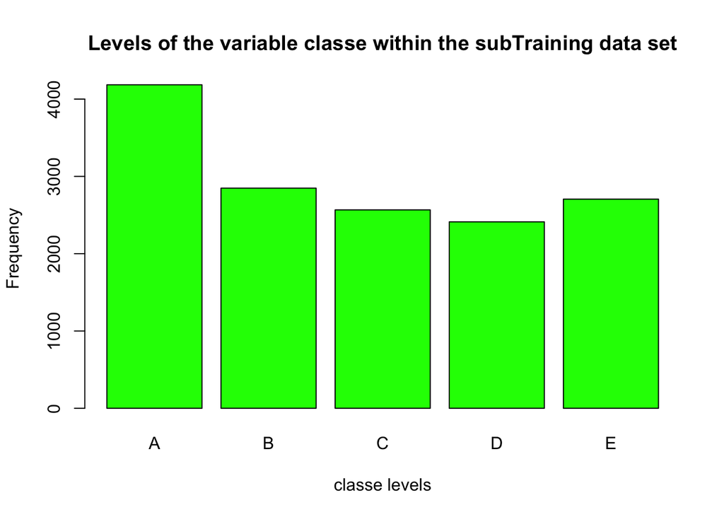

```r
plot(subTraining$classe, col="green", main="Levels of the variable classe within the subTraining data set", xlab="classe levels", ylab="Frequency")
```

## Prediction Model Using Decision Making Tree

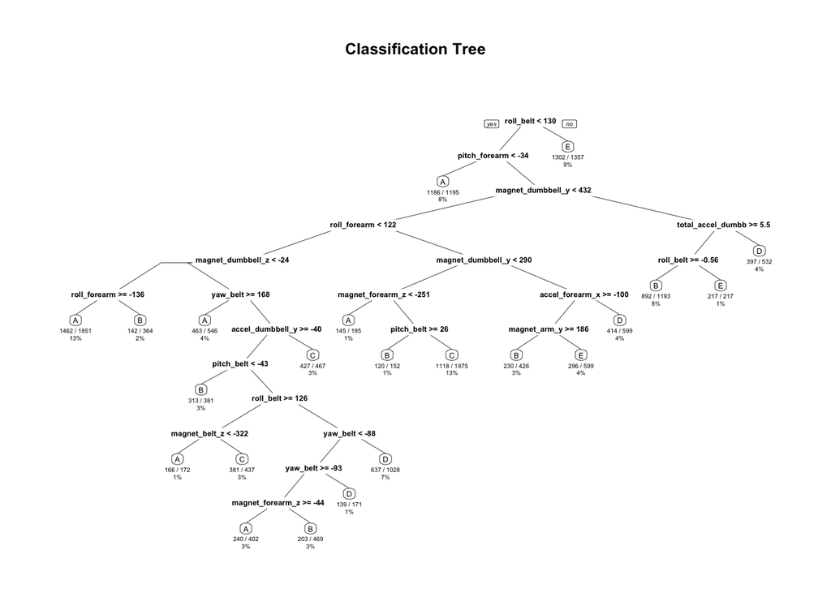

```r
modelA <- rpart(classe ~ ., data=subTraining, method="class")
predictionA<- predict(modelA, subTesting, type = "class")
rpart.plot(modelA, main="Classification Tree", extra=102, under=TRUE, faclen=0)
```

```r
confusionMatrix(predictionA, subTesting$classe)
```

```
## Confusion Matrix and Statistics
##
##           Reference
## Prediction    A    B    C    D    E
##          A 1189  144   24   31   35
##          B   70  653  117   88  113
##          C   33   68  643  125  102
##          D   65   55   47  520   79
##          E   38   29   24   40  572
##
## Overall Statistics
##
##                Accuracy : 0.7294
##                  95% CI : (0.7167, 0.7418)
##     No Information Rate : 0.2845
##     P-Value [Acc > NIR] : < 2.2e-16
##
##                   Kappa : 0.6574
##  Mcnemar's Test P-Value : < 2.2e-16
##
## Statistics by Class:
##
##                      Class: A Class: B Class: C Class: D Class: E
## Sensitivity            0.8523   0.6881   0.7520   0.6468   0.6349
## Specificity            0.9333   0.9019   0.9190   0.9400   0.9673
## Pos Pred Value         0.8356   0.6273   0.6622   0.6789   0.8137
## Neg Pred Value         0.9408   0.9234   0.9461   0.9314   0.9217
## Prevalence             0.2845   0.1935   0.1743   0.1639   0.1837
## Detection Rate         0.2425   0.1332   0.1311   0.1060   0.1166
## Detection Prevalence   0.2902   0.2123   0.1980   0.1562   0.1434
## Balanced Accuracy      0.8928   0.7950   0.8355   0.7934   0.8011
```

## Prediction Model Using Random Forest

```r
modelB <- randomForest(classe ~. , data=subTraining, method="class")
predictionB<- predict(modelB, subTesting, type = "class")
confusionMatrix(predictionB, subTesting$classe)
```

```
## Confusion Matrix and Statistics
##
##           Reference
## Prediction    A    B    C    D    E
##          A 1393    4    0    0    0
##          B    1  943    6    0    0
##          C    0    2  848    7    0
##          D    0    0    1  796    2
##          E    1    0    0    1  899
##
## Overall Statistics
##
##                Accuracy : 0.9949
##                  95% CI : (0.9925, 0.9967)
##     No Information Rate : 0.2845
##     P-Value [Acc > NIR] : < 2.2e-16
##
##                   Kappa : 0.9936
##  Mcnemar's Test P-Value : NA
##
## Statistics by Class:
##
##                      Class: A Class: B Class: C Class: D Class: E
## Sensitivity            0.9986   0.9937   0.9918   0.9900   0.9978
## Specificity            0.9989   0.9982   0.9978   0.9993   0.9995
## Pos Pred Value         0.9971   0.9926   0.9895   0.9962   0.9978
## Neg Pred Value         0.9994   0.9985   0.9983   0.9981   0.9995
## Prevalence             0.2845   0.1935   0.1743   0.1639   0.1837
## Detection Rate         0.2841   0.1923   0.1729   0.1623   0.1833
## Detection Prevalence   0.2849   0.1937   0.1748   0.1629   0.1837
## Balanced Accuracy      0.9987   0.9960   0.9948   0.9947   0.9986
```

## Decision

The Random Forest prediction Model is more accurate than the Decision Tree model. The out of sample error is 0.5%. The Random Forest Model will be choosen.

## Final Prediction Model

```r
finalmodel<-predict(modelB,testingset,type="class")
finalmodel
```

```
##  1  2  3  4  5  6  7  8  9 10 11 12 13 14 15 16 17 18 19 20
##  B  A  B  A  A  E  D  B  A  A  B  C  B  A  E  E  A  B  B  B
## Levels: A B C D E
```